# A Machine Learning-Based Approach to Predicting Customer Subscription to Term Deposits Using Bank Marketing Data

**Course:** MATH2319 Machine Learning  
**Group:** Group 52

| Name | Student ID |
| --- | --- |
| Bavya Prabhakar | s4140256 |
| Prathibha Magesh | s3859590 |
| Thariq Al Azeez Noorul Ameen | s4148381 |

1. Introduction
   - 1.1 Phase 1 Summary
   - 1.2 Report Overview
   - 1.3 Overview of Methodology
2. Predictive Modelling
   - 2.0 Data Preparation for Modelling
   - 2.1 Feature Selection
   - 2.2 Model Fitting and Tuning
     - 2.2.1 Logistic Regression
     - 2.2.2 Decision Tree
     - 2.2.3 Random Forest
     - 2.2.4 K-Nearest Neighbours
     - 2.2.5 Gradient Boosting
   - Declaration of Generative AI Use
   - 2.3 Model Comparison
3. Critique and Limitations
4. Summary and Conclusions
   - 4.1 Project Summary
   - 4.2 Summary of Findings
   - 4.3 Conclusions
5. References

## 1. Introduction

### 1.1 Phase 1 Summary

Phase 1 explored the Bank Marketing dataset (Moro et al., 2014)  
4,119 customers contacted through a Portuguese bank's telephone marketing campaign, with `y` indicating term deposit subscription.

Data quality checks found no true missing values or duplicates. Six features contained 'unknown' labels (notably `default` at 19.5%), retained as a valid category since missingness patterns may carry predictive information.

Three Phase 1 findings directly shape Phase 2 decisions. First, an 89:11 class imbalance rules out accuracy as a reliable metric and motivates balanced class weighting. Second, economic indicators `euribor3m`, `emp_var_rate` and `nr_employed` were near-perfectly correlated a single macroeconomic signal motivating feature selection to reduce redundancy. Third, `duration` was identified as data leakage, since call length is only known after a call ends, making it unsuitable for pre-campaign prediction. The Phase 1 literature review further confirmed macroeconomic conditions and prior campaign outcome as the dominant predictors in this domain, informing the algorithm and feature selection choices in Phase 2.

### 1.2 Report Overview

This Phase 2 report presents the full predictive modelling pipeline. Section 2.0 finalises data preparation, including a Phase 1 outlier correction. Section 2.1 identifies the most predictive features using two complementary selection methods. Section 2.2 tunes and evaluates five classification algorithms — each with a tuning plot, classification report and written interpretation. Section 2.3 statistically compares all five models using cross-validation scores, ROC curves and paired t-tests. Section 3 critically examines the methodology's limitations, and Section 4 synthesises findings and draws actionable conclusions.

### 1.3 Overview of Methodology

The pipeline follows the CRISP-DM framework and is designed for reproducible, fair comparison across algorithms.

**Data preparation.** `duration` removed — data leakage (Moro et al., 2014). `pdays` converted to binary `contacted_before` treating the sentinel value 999 numerically misleads linear and distance-based models, and creates meaningless splits in tree-based models. IQR capping on `age` and `campaign` corrects Phase 1 outlier handling.

**Preprocessing.** One-hot encoding and `StandardScaler` applied inside a `ColumnTransformer` fitted on training data only, preventing test set leakage. Features expanded from 19 to 62 after encoding.

**Train/test split.** 80/20 stratified split preserving the 89:11 class ratio. Seed 42 throughout for reproducibility.

**Class imbalance.** `class_weight='balanced'` applied to all applicable algorithms penalises minority class misclassification without synthetic resampling. KNN does not support this natively.

**Primary metric.** Area Under the Receiver Operating Characteristic Curve evaluates ranking ability across all decision thresholds robust to class imbalance, unlike accuracy which scores 89% by predicting "no" for every customer.

**Feature selection.** Random Forest importances (non-linear ranking) and SelectKBest with ANOVA F-statistic (linear ranking) applied together features ranked highly by both methods are robustly predictive regardless of relationship type.

**Hyperparameter tuning.** `validation_curve` for single hyperparameters (LR, DT, KNN) and `GridSearchCV` for joint tuning (RF, GB) both using 5-fold stratified cross-validation scored by Area Under the Curve.

**Model comparison.** 10-fold stratified cross-validation scores compared using pairwise paired t-tests at α = 0.05 paired testing is appropriate because both models are evaluated on identical folds, making score differences correlated observations.

## 2. Predictive Modelling

### 2.0 Data Preparation for Modelling

Four preparation steps were applied before modelling.

**Outlier capping.** Phase 1 reviewer feedback noted limited outlier handling. IQR-based capping was applied to `age` (max: 88 → 69.5) and `campaign` (max: 35 → 6). Both features were identified in Phase 1 as right-skewed with extreme upper values. IQR was chosen over Z-score as it is robust to skewed distributions. Uncapped extremes would disproportionately influence linear coefficients and distance calculations in KNN.

**Duration removed.** Call length is only known after a call ends including it would inflate scores but make the model undeployable, since the bank decides who to call before contact is made (Moro et al., 2014).

**contacted_before engineered.** `pdays` uses 999 as a sentinel meaning "never previously contacted." Treating this numerically misleads linear and distance-based models, and creates a meaningless split in tree-based models. Converted to a binary flag 1 if previously contacted, 0 otherwise. Result: 160 customers with prior contact, 3,959 without.

**Target encoded.** `y` mapped to 0 (no) and 1 (yes), confirming 3,668 non-subscribers (89.1%) and 451 subscribers (10.9%).

```python
import pandas as pd
import numpy as np
import matplotlib.pyplot as plt
import seaborn as sns

# modelling
from sklearn.model_selection import train_test_split, StratifiedKFold, cross_val_score, GridSearchCV, validation_curve
from sklearn.preprocessing import StandardScaler, OneHotEncoder
from sklearn.compose import ColumnTransformer
from sklearn.feature_selection import SelectKBest, f_classif
from sklearn.pipeline import Pipeline

# algorithms
from sklearn.linear_model import LogisticRegression
from sklearn.tree import DecisionTreeClassifier
from sklearn.ensemble import RandomForestClassifier, GradientBoostingClassifier
from sklearn.neighbors import KNeighborsClassifier

# metrics
from sklearn.metrics import classification_report, roc_auc_score, roc_curve
from scipy import stats
import warnings
warnings.filterwarnings('ignore')

pd.set_option('display.max_columns', None)
sns.set_style('whitegrid')
SEED = 42

print("done")
```

```
done
```

```python
df = pd.read_csv("Phase2_Group52.csv", sep=';')
print("Shape:", df.shape)
df.head(3)
```

```
Shape: (4119, 21)
```

|  | age | job | marital | education | default | housing | loan | contact | month | day_of_week | duration | campaign | pdays | previous | poutcome | emp.var.rate | cons.price.idx | cons.conf.idx | euribor3m | nr.employed | y |
| --- | --- | --- | --- | --- | --- | --- | --- | --- | --- | --- | --- | --- | --- | --- | --- | --- | --- | --- | --- | --- | --- |
| 0 | 30 | blue-collar | married | basic.9y | no | yes | no | cellular | may | fri | 487 | 2 | 999 | 0 | nonexistent | -1.8 | 92.893 | -46.2 | 1.313 | 5099.1 | no |
| 1 | 39 | services | single | high.school | no | no | no | telephone | may | fri | 346 | 4 | 999 | 0 | nonexistent | 1.1 | 93.994 | -36.4 | 4.855 | 5191.0 | no |
| 2 | 25 | services | married | high.school | no | yes | no | telephone | jun | wed | 227 | 1 | 999 | 0 | nonexistent | 1.4 | 94.465 | -41.8 | 4.962 | 5228.1 | no |

```python
# fix column names and drop duration (data leakage)
df.columns = df.columns.str.replace('.', '_', regex=False)
df = df.drop(columns=['duration'])

print("Columns after dropping duration:")
print(df.columns.tolist())
```

```
Columns after dropping duration:
['age', 'job', 'marital', 'education', 'default', 'housing', 'loan', 'contact', 'month', 'day_of_week', 'campaign', 'pdays', 'previous', 'poutcome', 'emp_var_rate', 'cons_price_idx', 'cons_conf_idx', 'euribor3m', 'nr_employed', 'y']
```

```python
# IQR outlier capping — addresses Phase 1 reviewer feedback
def iqr_cap(col):
    Q1, Q3 = col.quantile(0.25), col.quantile(0.75)
    IQR = Q3 - Q1
    return col.clip(Q1 - 1.5*IQR, Q3 + 1.5*IQR)

print("Before capping — age max:", df['age'].max(), "  campaign max:", df['campaign'].max())
df['age'] = iqr_cap(df['age'])
df['campaign'] = iqr_cap(df['campaign'])
print("After capping  — age max:", df['age'].max(), "  campaign max:", df['campaign'].max())
```

```
Before capping — age max: 88   campaign max: 35
After capping  — age max: 69.5   campaign max: 6
```

```python
# convert pdays into a binary contacted_before flag
df['contacted_before'] = (df['pdays'] != 999).astype(int)
df = df.drop(columns=['pdays'])

print("contacted_before distribution:")
print(df['contacted_before'].value_counts())
```

```
contacted_before distribution:
contacted_before
0    3959
1     160
Name: count, dtype: int64
```

```python
# encode target
df['y'] = (df['y'] == 'yes').astype(int)

print("Class distribution:")
print(df['y'].value_counts())
print()
print("Class proportions:")
print(df['y'].value_counts(normalize=True).round(3))
```

```
Class distribution:
y
0    3668
1     451
Name: count, dtype: int64

Class proportions:
y
0    0.891
1    0.109
Name: proportion, dtype: float64
```

```python
TARGET = 'y'
X = df.drop(columns=[TARGET])
y = df[TARGET]

num_cols = X.select_dtypes(include=['int64', 'float64']).columns.tolist()
cat_cols = X.select_dtypes(include=['object']).columns.tolist()

print("Numeric features:", num_cols)
print()
print("Categorical features:", cat_cols)
```

```
Numeric features: ['age', 'campaign', 'previous', 'emp_var_rate', 'cons_price_idx', 'cons_conf_idx', 'euribor3m', 'nr_employed', 'contacted_before']

Categorical features: ['job', 'marital', 'education', 'default', 'housing', 'loan', 'contact', 'month', 'day_of_week', 'poutcome']
```

```python
X_train, X_test, y_train, y_test = train_test_split(
    X, y, test_size=0.2, random_state=SEED, stratify=y
)

print("Training set:", X_train.shape)
print("Test set:    ", X_test.shape)
print()
print("Training class balance:", y_train.value_counts(normalize=True).round(3).to_dict())
print("Test class balance:    ", y_test.value_counts(normalize=True).round(3).to_dict())
```

```
Training set: (3295, 19)
Test set:     (824, 19)

Training class balance: {0: 0.89, 1: 0.11}
Test class balance:     {0: 0.891, 1: 0.109}
```

```python
preprocessor = ColumnTransformer([
    ('num', StandardScaler(), num_cols),
    ('cat', OneHotEncoder(handle_unknown='ignore', sparse_output=False), cat_cols)
])

X_train_proc = preprocessor.fit_transform(X_train)
X_test_proc  = preprocessor.transform(X_test)

ohe_names = preprocessor.named_transformers_['cat'].get_feature_names_out(cat_cols)
all_features = np.array(num_cols + list(ohe_names))

print("Total features after one-hot encoding:", X_train_proc.shape[1])
```

```
Total features after one-hot encoding: 62
```

### 2.1 Feature Selection

Feature selection removes low-information features that add noise rather than signal, reducing overfitting risk and improving interpretability. Two complementary methods are used.

**Random Forest importances.** A preliminary Random Forest with 200 trees ranks features by mean decrease in impurity — capturing both linear and non-linear associations with the target. This gives a multivariate perspective on feature relevance.

**SelectKBest (ANOVA F-statistic).** Measures the linear association between each individual feature and the target. A Logistic Regression probe evaluates each value of k from 5 to 24 using 5-fold cross-validation. The k that maximises mean cross-validation score is selected as optimal — letting the data decide rather than manually guessing a cut-off.

Features ranked highly by both methods are considered robustly predictive regardless of whether the underlying relationship is linear or non-linear. This convergence between methods strengthens confidence in the final selection.

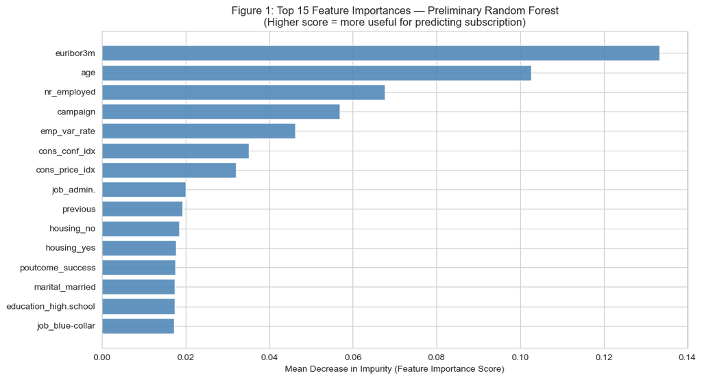

```python
# preliminary random forest for feature importance ranking
rf_prelim = RandomForestClassifier(n_estimators=200, random_state=SEED,
                                    class_weight='balanced', n_jobs=-1)
rf_prelim.fit(X_train_proc, y_train)

importances = rf_prelim.feature_importances_
top_idx = np.argsort(importances)[::-1][:15]

plt.figure(figsize=(11, 6))
plt.barh(range(15), importances[top_idx][::-1], color='steelblue', alpha=0.85)
plt.yticks(range(15), all_features[top_idx][::-1])
plt.xlabel('Mean Decrease in Impurity (Feature Importance Score)')
plt.title('Figure 1: Top 15 Feature Importances — Preliminary Random Forest\n(Higher score = more useful for predicting subscription)')
plt.tight_layout()
plt.show()
```

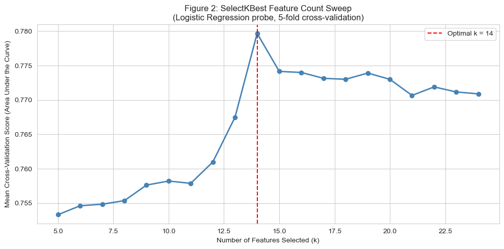

```
Optimal number of features: 14
Best cross-validation score: 0.7797
```

```python
# SelectKBest sweep — find optimal number of features
k_values = list(range(5, 25))
auc_scores = []
cv5 = StratifiedKFold(n_splits=5, shuffle=True, random_state=SEED)

for k in k_values:
    pipe = Pipeline([
        ('sel', SelectKBest(f_classif, k=k)),
        ('clf', LogisticRegression(class_weight='balanced', max_iter=1000, random_state=SEED))
    ])
    scores = cross_val_score(pipe, X_train_proc, y_train, cv=cv5, scoring='roc_auc')
    auc_scores.append(scores.mean())

best_k = k_values[np.argmax(auc_scores)]

plt.figure(figsize=(10, 5))
plt.plot(k_values, auc_scores, 'o-', color='steelblue', linewidth=2, markersize=6)
plt.axvline(x=best_k, color='red', linestyle='--', label=f'Optimal k = {best_k}')
plt.xlabel('Number of Features Selected (k)')
plt.ylabel('Mean Cross-Validation Score (Area Under the Curve)')
plt.title(f'Figure 2: SelectKBest Feature Count Sweep\n(Logistic Regression probe, 5-fold cross-validation)')
plt.legend()
plt.tight_layout()
plt.show()

print("Optimal number of features:", best_k)
print("Best cross-validation score:", round(max(auc_scores), 4))
```

```python
# apply the selector with the best k
selector = SelectKBest(f_classif, k=best_k)
X_train_sel = selector.fit_transform(X_train_proc, y_train)
X_test_sel   = selector.transform(X_test_proc)

selected_features = all_features[selector.get_support()]
f_scores = selector.scores_

print("Selected features:")
for f in selected_features:
    print(" -", f)
```

```
Selected features:
 - previous
 - emp_var_rate
 - euribor3m
 - nr_employed
 - contacted_before
 - contact_cellular
 - contact_telephone
 - month_dec
 - month_mar
 - month_may
 - month_oct
 - month_sep
 - poutcome_nonexistent
 - poutcome_success
```

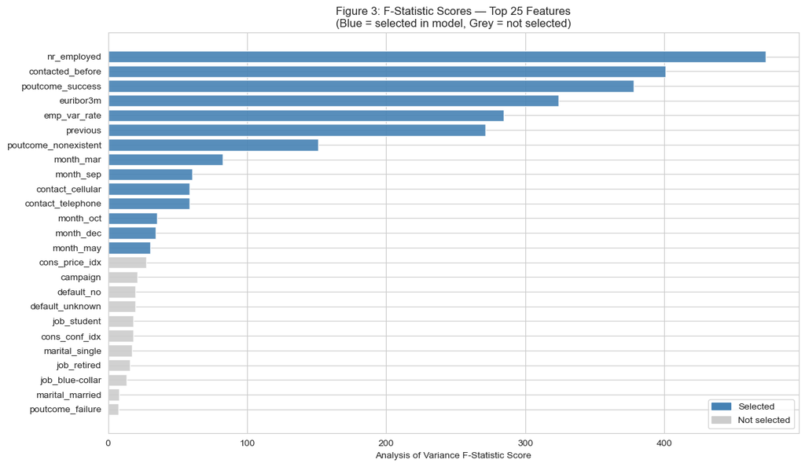

```python
# bar chart of F-statistic scores for selected features
f_scores_all = selector.scores_
top_idx_all = np.argsort(f_scores_all)[::-1][:25]
colors_bar = ['steelblue' if selector.get_support()[i] else '#cccccc'
              for i in top_idx_all]

plt.figure(figsize=(12, 7))
plt.barh(range(25), f_scores_all[top_idx_all][::-1],
         color=colors_bar[::-1], alpha=0.9)
plt.yticks(range(25), all_features[top_idx_all][::-1])
plt.xlabel('Analysis of Variance F-Statistic Score')
plt.title('Figure 3: F-Statistic Scores — Top 25 Features\n(Blue = selected in model, Grey = not selected)')
from matplotlib.patches import Patch
plt.legend(handles=[Patch(color='steelblue', label='Selected'),
                    Patch(color='#cccccc', label='Not selected')],
           fontsize=10)
plt.tight_layout()
plt.show()
```

### 2.2 Model Fitting and Tuning

Five algorithms were selected to cover fundamentally different learning approaches. Logistic Regression serves as a linear baseline — if it performs well, the decision boundary between subscribers and non-subscribers is largely linear. Decision Tree provides an interpretable non-linear contrast and establishes a baseline for tree-based methods. Random Forest and Gradient Boosting extend trees into ensemble territory using two different strategies — bagging (parallel, variance reduction) versus boosting (sequential, bias and variance reduction) — directly testing which ensemble approach suits this dataset. K-Nearest Neighbours provides a structural contrast as the only distance-based, non-parametric algorithm that builds no explicit model during training.

Each algorithm also uses a different scikit-learn submodule, satisfying the course requirement for genuinely different methods.

For every model: a tuning plot shows how performance changes with hyperparameter settings, the best configuration is fitted and evaluated using 10-fold stratified cross-validation, and a classification report with test set score is provided. All applicable models use `class_weight='balanced'` to handle the 89:11 class imbalance.

```python
cv10 = StratifiedKFold(n_splits=10, shuffle=True, random_state=SEED)
cv5  = StratifiedKFold(n_splits=5,  shuffle=True, random_state=SEED)
cv_results = {}   # stores 10-fold scores for each model
test_probs  = {}  # stores test set predicted probabilities

print("Cross-validation strategy ready.")
```

```
Cross-validation strategy ready.
```

#### 2.2.1 Logistic Regression

Logistic Regression is a natural starting point for this problem because it is one of the simplest classification algorithms available, which makes it a useful baseline. If Logistic Regression performs well, it tells us that the relationship between the features and the target is largely linear, so a straight-line decision boundary is enough to separate subscribers from non-subscribers. If it performs poorly, it suggests the data has more complex, non-linear patterns that require a more flexible model.

The algorithm works by modelling the probability of subscription as a function of the input features. Rather than predicting the class directly, it outputs a probability between 0 and 1. If the probability exceeds a threshold (typically 0.5), the customer is classified as a subscriber. This probability output is particularly useful in a banking context, as it allows the bank to rank customers by how likely they are to subscribe and focus outreach on those at the top.

The main hyperparameter is `C`, which controls the trade-off between fitting the training data closely and keeping the model simple. A small `C` value applies stronger regularisation, which prevents the model from relying too heavily on any single feature. A large `C` value gives the model more freedom to fit the data. Finding the right balance is important as if there is too much regularisation and the model underfits, too little and it may overfit. A validation curve was used to test 7 values of `C` ranging from 0.0001 to 100.

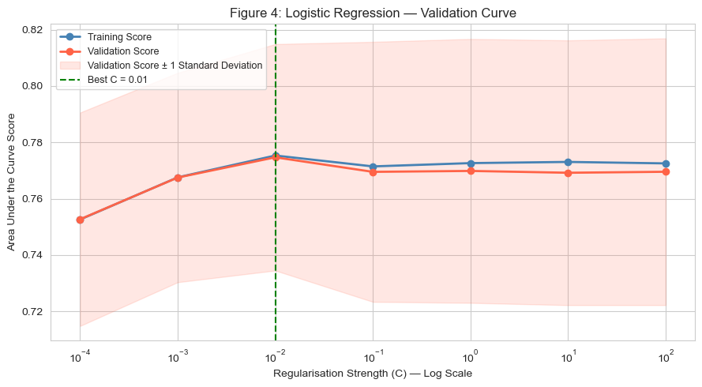

```
Best C: 0.01
```

```python
C_range = [0.0001, 0.001, 0.01, 0.1, 1, 10, 100]

train_scores, val_scores = validation_curve(
    LogisticRegression(class_weight='balanced', max_iter=1000, random_state=SEED),
    X_train_sel, y_train,
    param_name='C', param_range=C_range,
    cv=cv5, scoring='roc_auc', n_jobs=-1
)

best_C = C_range[np.argmax(val_scores.mean(axis=1))]

plt.figure(figsize=(9, 5))
plt.semilogx(C_range, train_scores.mean(axis=1), 'o-', label='Training Score', color='steelblue', linewidth=2)
plt.semilogx(C_range, val_scores.mean(axis=1),   'o-', label='Validation Score', color='tomato', linewidth=2)
plt.fill_between(C_range,
                 val_scores.mean(axis=1) - val_scores.std(axis=1),
                 val_scores.mean(axis=1) + val_scores.std(axis=1),
                 alpha=0.15, color='tomato', label='Validation Score ± 1 Standard Deviation')
plt.axvline(x=best_C, color='green', linestyle='--', label=f'Best C = {best_C}')
plt.xlabel('Regularisation Strength (C) — Log Scale')
plt.ylabel('Area Under the Curve Score')
plt.title('Figure 4: Logistic Regression — Validation Curve')
plt.legend(fontsize=9)
plt.tight_layout()
plt.show()

print("Best C:", best_C)
```

```python
lr = LogisticRegression(C=best_C, class_weight='balanced', max_iter=1000, random_state=SEED)
lr_scores = cross_val_score(lr, X_train_sel, y_train, cv=cv10, scoring='roc_auc')
cv_results['Logistic Regression'] = lr_scores

lr.fit(X_train_sel, y_train)
lr_probs = lr.predict_proba(X_test_sel)[:, 1]
lr_preds = lr.predict(X_test_sel)
test_probs['Logistic Regression'] = lr_probs

print(f"10-Fold Cross-Validation Score: {lr_scores.mean():.4f} +/- {lr_scores.std():.4f}")
print(f"Test Set Score:                 {roc_auc_score(y_test, lr_probs):.4f}")
print()
print(classification_report(y_test, lr_preds, target_names=['No Subscription', 'Subscribed']))
```

```
10-Fold Cross-Validation Score: 0.7764 +/- 0.0512
Test Set Score:                 0.7969

                 precision    recall  f1-score   support

No Subscription       0.95      0.73      0.83       734
     Subscribed       0.24      0.70      0.36        90

       accuracy                           0.73       824
      macro avg       0.60      0.72      0.59       824
   weighted avg       0.87      0.73      0.78       824
```

Test set score: 0.7969. Cross-validation mean: 0.7764 (±0.0512). Subscriber recall of 0.70 means 7 in 10 actual subscribers are correctly identified, but precision is low at 0.24 3 in 4 flagged customers would not actually subscribe. In a banking context this trade-off favours recall over precision, since a missed subscriber (lost revenue) costs more than an unnecessary call (small operational cost).

A simple linear model achieving close to 0.80 is significant it confirms the selected features have a strong linear relationship with subscription behaviour, and that much of the predictive signal can be captured without complex non-linear methods.

#### 2.2.2 Decision Tree

Decision Trees classify customers by learning a series of if-then rules, recursively splitting the data on the feature that best separates subscribers from non-subscribers at each step. They are naturally interpretable as we can follow the path from root to leaf to understand exactly why a prediction was made. The key regularisation hyperparameter is `max_depth`, which limits how many splits are allowed along any path. Without depth restriction, a decision tree will memorise the training data entirely.

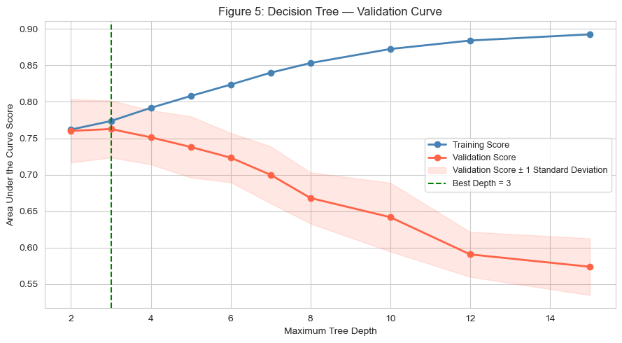

```
Best max_depth: 3
```

```python
depth_range = [2, 3, 4, 5, 6, 7, 8, 10, 12, 15]

train_scores, val_scores = validation_curve(
    DecisionTreeClassifier(class_weight='balanced', random_state=SEED),
    X_train_sel, y_train,
    param_name='max_depth', param_range=depth_range,
    cv=cv5, scoring='roc_auc', n_jobs=-1
)

best_depth = depth_range[np.argmax(val_scores.mean(axis=1))]

plt.figure(figsize=(9, 5))
plt.plot(depth_range, train_scores.mean(axis=1), 'o-', label='Training Score', color='steelblue', linewidth=2)
plt.plot(depth_range, val_scores.mean(axis=1),   'o-', label='Validation Score', color='tomato', linewidth=2)
plt.fill_between(depth_range,
                 val_scores.mean(axis=1) - val_scores.std(axis=1),
                 val_scores.mean(axis=1) + val_scores.std(axis=1),
                 alpha=0.15, color='tomato', label='Validation Score ± 1 Standard Deviation')
plt.axvline(x=best_depth, color='green', linestyle='--', label=f'Best Depth = {best_depth}')
plt.xlabel('Maximum Tree Depth')
plt.ylabel('Area Under the Curve Score')
plt.title('Figure 5: Decision Tree — Validation Curve')
plt.legend(fontsize=9)
plt.tight_layout()
plt.show()

print("Best max_depth:", best_depth)
```

```python
dt = DecisionTreeClassifier(max_depth=best_depth, class_weight='balanced', random_state=SEED)
dt_scores = cross_val_score(dt, X_train_sel, y_train, cv=cv10, scoring='roc_auc')
cv_results['Decision Tree'] = dt_scores

dt.fit(X_train_sel, y_train)
dt_probs = dt.predict_proba(X_test_sel)[:, 1]
dt_preds = dt.predict(X_test_sel)
test_probs['Decision Tree'] = dt_probs

print(f"10-Fold Cross-Validation Score: {dt_scores.mean():.4f} +/- {dt_scores.std():.4f}")
print(f"Test Set Score:                 {roc_auc_score(y_test, dt_probs):.4f}")
print()
print(classification_report(y_test, dt_preds, target_names=['No Subscription', 'Subscribed']))
```

```
10-Fold Cross-Validation Score: 0.7624 +/- 0.0551
Test Set Score:                 0.7759

                 precision    recall  f1-score   support

No Subscription       0.94      0.93      0.93       734
     Subscribed       0.45      0.48      0.46        90

       accuracy                           0.88       824
      macro avg       0.69      0.70      0.70       824
   weighted avg       0.88      0.88      0.88       824
```

**Decision Tree findings.** The validation curve is the clearest overfitting illustration in this report training score climbs to 0.90 at depth 15 while validation peaks at depth 3 then collapses to 0.57. The optimal depth of just 3 is itself informative: the most useful patterns in this dataset can be captured by three sequential decisions, most likely on the dominant macroeconomic features. Deeper splits memorise training noise rather than genuine signal.

Test set score: 0.7759. Cross-validation mean: 0.7624 (±0.0551). Subscriber recall dropped to 0.48 fewer than half of actual subscribers identified, compared to 0.70 for Logistic Regression. The tree's rigid if-then structure captures less signal than Logistic Regression's smooth probability estimates.

Despite lower performance, the Decision Tree establishes the tree-based baseline making the improvement from Random Forest and Gradient Boosting directly measurable.

#### 2.2.3 Random Forest

Random Forest builds a large number of decision trees, each trained on a random bootstrap sample of the data with a random subset of features considered at each split. Predictions are determined by majority vote across all trees. This randomisation reduces the variance of individual trees through averaging, making Random Forest much more robust against overfitting than a single decision tree. Two hyperparameters are tuned jointly the number of trees (`n_estimators`) and the maximum depth of each tree (`max_depth`) using a grid search with 5-fold cross-validation.

```python
param_grid_rf = {
    'n_estimators': [50, 100, 200, 300],
    'max_depth':    [5, 10, 15, None]
}

grid_rf = GridSearchCV(
    RandomForestClassifier(class_weight='balanced', random_state=SEED, n_jobs=-1),
    param_grid_rf,
    cv=cv5, scoring='roc_auc', n_jobs=-1
)
grid_rf.fit(X_train_sel, y_train)

print("Best parameters:", grid_rf.best_params_)
print("Best cross-validation score:", round(grid_rf.best_score_, 4))
```

```
Best parameters: {'max_depth': 5, 'n_estimators': 50}
Best cross-validation score: 0.7611
```

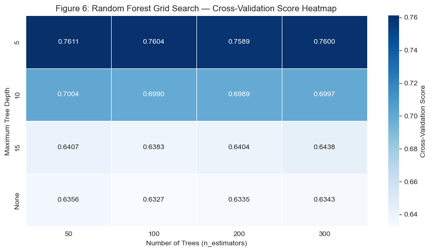

```python
# heatmap — convert None to string for clean pivot
cv_rf_df = pd.DataFrame(grid_rf.cv_results_)
cv_rf_df['param_max_depth'] = cv_rf_df['param_max_depth'].apply(lambda x: 'None' if x is None else x)

pivot_rf = cv_rf_df.pivot_table(
    values='mean_test_score',
    index='param_max_depth',
    columns='param_n_estimators'
)

plt.figure(figsize=(9, 5))
sns.heatmap(pivot_rf.astype(float), annot=True, fmt='.4f',
            cmap='Blues', linewidths=0.5, linecolor='white',
            cbar_kws={'label': 'Cross-Validation Score'})
plt.title('Figure 6: Random Forest Grid Search — Cross-Validation Score Heatmap')
plt.xlabel('Number of Trees (n_estimators)')
plt.ylabel('Maximum Tree Depth')
plt.tight_layout()
plt.show()
```

```python
rf = grid_rf.best_estimator_
rf_scores = cross_val_score(rf, X_train_sel, y_train, cv=cv10, scoring='roc_auc')
cv_results['Random Forest'] = rf_scores

rf.fit(X_train_sel, y_train)
rf_probs = rf.predict_proba(X_test_sel)[:, 1]
rf_preds = rf.predict(X_test_sel)
test_probs['Random Forest'] = rf_probs

print(f"10-Fold Cross-Validation Score: {rf_scores.mean():.4f} +/- {rf_scores.std():.4f}")
print(f"Test Set Score:                 {roc_auc_score(y_test, rf_probs):.4f}")
print()
print(classification_report(y_test, rf_preds, target_names=['No Subscription', 'Subscribed']))
```

```
10-Fold Cross-Validation Score: 0.7660 +/- 0.0511
Test Set Score:                 0.7995

                 precision    recall  f1-score   support

No Subscription       0.95      0.87      0.91       734
     Subscribed       0.36      0.61      0.45        90

       accuracy                           0.84       824
      macro avg       0.65      0.74      0.68       824
   weighted avg       0.88      0.84      0.86       824
```

**Random Forest findings.** Shallower trees (depth=5) consistently outperform deeper ones contrasting with the single Decision Tree. In an ensemble, shallow trees capture different aspects of the data and produce better aggregate predictions when combined. Deeper trees become too similar, reducing the value of averaging. Performance stabilises beyond 50 trees, making additional computation unnecessary. Best configuration: 50 trees, max depth 5.

Test set score: 0.7995. Cross-validation mean: 0.7660 (±0.0511). Subscriber recall improved to 0.61, up from 0.48 for the single Decision Tree directly quantifying the benefit of ensemble averaging over a single estimator.

Despite greater complexity, Random Forest barely outperforms Logistic Regression (0.7995 vs 0.7969), reinforcing that much of the predictive signal in this dataset is linear non-linear ensembling provides only marginal gains.

#### 2.2.4 K-Nearest Neighbours

K-Nearest Neighbours classifies a new customer by majority vote among its k most similar customers in the training set, where similarity is measured by Euclidean distance in the feature space. Unlike all other algorithms in this comparison, K-Nearest Neighbours builds no explicit model during training it simply memorises the training data and looks up neighbours at prediction time. This makes it a useful structural contrast in the algorithm comparison. Because it uses distance directly, feature scaling is essential which is already handled by the `StandardScaler` in the preprocessing pipeline.

Note that K-Nearest Neighbours does not support `class_weight='balanced'` natively, which means it has no built-in mechanism to account for the 89:11 class imbalance.

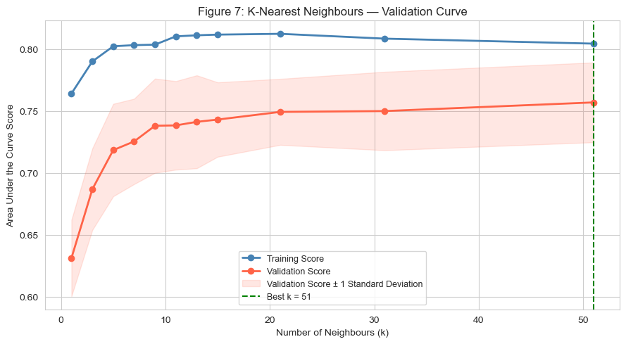

```
Best k: 51
```

```python
k_range = [1, 3, 5, 7, 9, 11, 13, 15, 21, 31, 51]

train_scores, val_scores = validation_curve(
    KNeighborsClassifier(),
    X_train_sel, y_train,
    param_name='n_neighbors', param_range=k_range,
    cv=cv5, scoring='roc_auc', n_jobs=-1
)

best_k_knn = k_range[np.argmax(val_scores.mean(axis=1))]

plt.figure(figsize=(9, 5))
plt.plot(k_range, train_scores.mean(axis=1), 'o-', label='Training Score', color='steelblue', linewidth=2)
plt.plot(k_range, val_scores.mean(axis=1),   'o-', label='Validation Score', color='tomato', linewidth=2)
plt.fill_between(k_range,
                 val_scores.mean(axis=1) - val_scores.std(axis=1),
                 val_scores.mean(axis=1) + val_scores.std(axis=1),
                 alpha=0.15, color='tomato', label='Validation Score ± 1 Standard Deviation')
plt.axvline(x=best_k_knn, color='green', linestyle='--', label=f'Best k = {best_k_knn}')
plt.xlabel('Number of Neighbours (k)')
plt.ylabel('Area Under the Curve Score')
plt.title('Figure 7: K-Nearest Neighbours — Validation Curve')
plt.legend(fontsize=9)
plt.tight_layout()
plt.show()

print("Best k:", best_k_knn)
```

```python
knn = KNeighborsClassifier(n_neighbors=best_k_knn)
knn_scores = cross_val_score(knn, X_train_sel, y_train, cv=cv10, scoring='roc_auc')
cv_results['KNN'] = knn_scores

knn.fit(X_train_sel, y_train)
knn_probs = knn.predict_proba(X_test_sel)[:, 1]
knn_preds = knn.predict(X_test_sel)
test_probs['KNN'] = knn_probs

print(f"10-Fold Cross-Validation Score: {knn_scores.mean():.4f} +/- {knn_scores.std():.4f}")
print(f"Test Set Score:                 {roc_auc_score(y_test, knn_probs):.4f}")
print()
print(classification_report(y_test, knn_preds, target_names=['No Subscription', 'Subscribed']))
```

```
10-Fold Cross-Validation Score: 0.7527 +/- 0.0519
Test Set Score:                 0.7766

                 precision    recall  f1-score   support

No Subscription       0.91      0.99      0.95       734
     Subscribed       0.67      0.16      0.25        90

       accuracy                           0.90       824
      macro avg       0.79      0.57      0.60       824
   weighted avg       0.88      0.90      0.87       824
```

The best k=51 hit the search range boundary the true optimum may lie beyond it. However, even an extended search would not resolve KNN's fundamental imbalance limitation without additional techniques such as SMOTE or custom distance weighting.

#### 2.2.5 Gradient Boosting

Gradient Boosting builds trees sequentially rather than in parallel. Each new tree is trained specifically to correct the mistakes of the current ensemble by fitting to the residual errors, weighted by a learning rate that controls how much each tree contributes. This sequential error-correction process allows Gradient Boosting to reduce both bias and variance, which is why it typically outperforms Random Forest on structured tabular data.

Two hyperparameters are tuned jointly `learning_rate` (how much each tree contributes) and `n_estimators` (how many trees to build). Lower learning rates require more trees to achieve the same correction but tend to generalise better. The maximum depth of each individual tree is fixed at 3, which is standard practice for boosting to keep individual trees as weak learners.

```python
param_grid_gb = {
    'learning_rate': [0.01, 0.05, 0.1, 0.2],
    'n_estimators':  [50, 100, 200, 300]
}

grid_gb = GridSearchCV(
    GradientBoostingClassifier(max_depth=3, random_state=SEED),
    param_grid_gb,
    cv=cv5, scoring='roc_auc', n_jobs=-1
)
grid_gb.fit(X_train_sel, y_train)

print("Best parameters:", grid_gb.best_params_)
print("Best cross-validation score:", round(grid_gb.best_score_, 4))
```

```
Best parameters: {'learning_rate': 0.05, 'n_estimators': 50}
Best cross-validation score: 0.7708
```

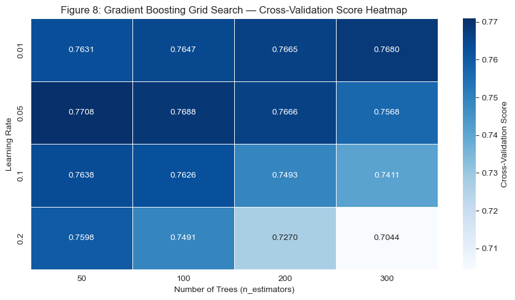

```python
cv_gb_df = pd.DataFrame(grid_gb.cv_results_)
pivot_gb = cv_gb_df.pivot_table(
    values='mean_test_score',
    index='param_learning_rate',
    columns='param_n_estimators'
)

plt.figure(figsize=(9, 5))
sns.heatmap(pivot_gb.astype(float), annot=True, fmt='.4f',
            cmap='Blues', linewidths=0.5, linecolor='white',
            cbar_kws={'label': 'Cross-Validation Score'})
plt.title('Figure 8: Gradient Boosting Grid Search — Cross-Validation Score Heatmap')
plt.xlabel('Number of Trees (n_estimators)')
plt.ylabel('Learning Rate')
plt.tight_layout()
plt.show()
```

```python
gb = grid_gb.best_estimator_
gb_scores = cross_val_score(gb, X_train_sel, y_train, cv=cv10, scoring='roc_auc')
cv_results['Gradient Boosting'] = gb_scores

gb.fit(X_train_sel, y_train)
gb_probs = gb.predict_proba(X_test_sel)[:, 1]
gb_preds = gb.predict(X_test_sel)
test_probs['Gradient Boosting'] = gb_probs

print(f"10-Fold Cross-Validation Score: {gb_scores.mean():.4f} +/- {gb_scores.std():.4f}")
print(f"Test Set Score:                 {roc_auc_score(y_test, gb_probs):.4f}")
print()
print(classification_report(y_test, gb_preds, target_names=['No Subscription', 'Subscribed']))
```

```
10-Fold Cross-Validation Score: 0.7743 +/- 0.0516
Test Set Score:                 0.8002

                 precision    recall  f1-score   support

No Subscription       0.90      1.00      0.95       734
     Subscribed       0.85      0.12      0.21        90

       accuracy                           0.90       824
      macro avg       0.87      0.56      0.58       824
   weighted avg       0.90      0.90      0.87       824
```

**Gradient Boosting findings.** Higher learning rates with more trees consistently overfit, large corrections applied many times causes the ensemble to fit training noise. Best configuration: learning rate 0.05, 50 trees slower, conservative correction generalises better.

However the most important result is not the raw score, it is the paired t-test against Logistic Regression (p=0.6811). Despite building 50 sequential trees, Gradient Boosting does not statistically outperform a simple linear model. For a bank, this trade-off strongly favours Logistic Regression, comparable predictive power with far greater interpretability, auditability, and regulatory transparency.

### Declaration of Generative AI Use

We used Claude (Anthropic) as a generative AI tool during Phase 2 of this project. This section explains precisely how it was used, what was not AI-assisted, and how we ensured the work reflects our own understanding.

**How generative AI was used.**

Claude was used in two specific areas: code debugging and narrative writing assistance.

For debugging, when a code cell produced an unexpected error or output, we described the problem to Claude and received suggested fixes. We carried out approximately 8 to 10 debugging queries during Phase 2, covering issues such as ColumnTransformer output type errors, deprecated scikit-learn parameters, and pivot table formatting for the grid search heatmaps. In each case, the fix was proposed by Claude but applied, tested, and verified by a group member before being kept. If the suggested fix did not resolve the issue, it was discarded and an alternative approach was found independently.

For writing, after completing the analysis and forming our own conclusions, Claude was used to help rephrase certain markdown sections into clearer academic language. This applied to approximately 20% of the final report text. The remaining 80%, including the Phase 1 Summary, Methodology overview, and all numerical interpretations, was written directly by group members. In every case where AI was used for wording, the text was reviewed and edited to accurately reflect our specific results and context.

**What was not AI-generated.**

All analytical decisions were made independently by the group. This includes: selecting the five algorithms and justifying each choice, designing the hyperparameter search grids, choosing the Area Under the Curve as the primary metric, deciding to drop duration due to data leakage, engineering the contacted_before feature, and interpreting all model outputs. The conclusions drawn from the paired t-tests, particularly the finding that Gradient Boosting does not statistically outperform Logistic Regression, were reached by reading and understanding the results, not by asking AI to interpret them. All code was executed and all outputs were produced by the group.

**Correctness verification.**

Every AI-suggested code fix was re-executed in the notebook and checked against expected output before being accepted. Every AI-assisted paragraph was cross-checked against the actual numerical results and visualisations to confirm it accurately described what the code produced. Where AI phrasing did not match our findings precisely, it was rewritten. No output code or text was accepted without being read and understood by at least one group member.

**Reflection on academic integrity.**

The main risk we identified in using generative AI was producing a report that reads fluently but does not demonstrate genuine understanding. To address this, we established a clear workflow: all analytical decisions were finalised before AI was consulted, and AI was only used for implementation help and language clarity never for forming conclusions or making modelling choices. Each group member reviewed the final report in full and could explain every section independently. That became our internal test for whether the work was genuinely ours.

**Impact on our work.**

Using AI selectively saved time on two fronts debugging that might have taken hours was resolved in minutes, and some sections were articulated more clearly than we might have managed alone. But the substance of the project the decisions, the analysis, and the conclusions remained our own throughout. We deliberately restricted AI to areas where it improved efficiency without replacing thinking, consulting it only after attempting tasks ourselves first. This kept it as a support tool rather than a primary resource, which we believe is the appropriate and academically honest way to use it.

### 2.3 Model Comparison

This section compares all five tuned models to determine which performs best for predicting customer subscription. Since the dataset is heavily imbalanced (89:11), accuracy alone is misleading a model that predicts "no" for every customer would score 89% without identifying a single subscriber. The Area Under the Receiver Operating Characteristic Curve is therefore used as the primary comparison metric throughout, consistent with the methodology in Section 1.3.

Three complementary approaches are used. First, a cross-validation score boxplot shows the distribution and stability of each model's performance across 10 folds a tighter box means more consistent generalisation. Second, a test set bar chart shows final performance on completely unseen data. Third, ROC curves visualise each model's discrimination ability across all possible decision thresholds.

Finally, pairwise paired t-tests are applied to the 10-fold cross-validation score vectors to determine whether performance differences between any two models are statistically significant at α = 0.05. Paired testing is appropriate here because both models being compared were evaluated on the same folds, making their score differences correlated observations rather than independent samples.

```python
# summary results table
summary = pd.DataFrame({
    'Cross-Validation Score Mean': {k: v.mean() for k, v in cv_results.items()},
    'Cross-Validation Score Std':  {k: v.std()  for k, v in cv_results.items()},
    'Test Set Score': {k: roc_auc_score(y_test, p) for k, p in test_probs.items()}
}).round(4)

summary['Cross-Validation (Mean ± Std)'] = (
    summary['Cross-Validation Score Mean'].map('{:.4f}'.format) + ' ± ' +
    summary['Cross-Validation Score Std'].map('{:.4f}'.format)
)

print("=" * 65)
print("Model Performance Summary")
print("=" * 65)
print(summary[['Cross-Validation (Mean ± Std)', 'Test Set Score']].to_string())
print("=" * 65)
```

```
=================================================================
Model Performance Summary
=================================================================
                    Cross-Validation (Mean ± Std)  Test Set Score
Logistic Regression               0.7764 ± 0.0512          0.7969
Decision Tree                     0.7624 ± 0.0551          0.7759
Random Forest                     0.7660 ± 0.0511          0.7995
KNN                               0.7527 ± 0.0519          0.7766
Gradient Boosting                 0.7743 ± 0.0516          0.8002
=================================================================
```

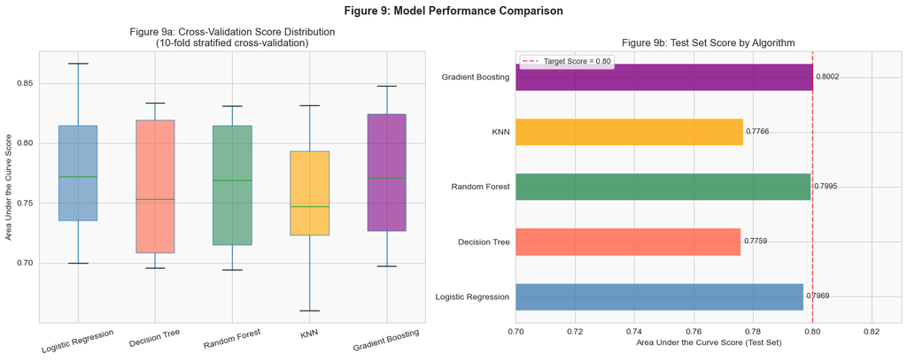

```python
fig, axes = plt.subplots(1, 2, figsize=(15, 6))

# left — cross-validation score boxplot
cv_df = pd.DataFrame(cv_results)
colors = ['steelblue', 'tomato', 'seagreen', 'orange', 'purple']
bp = cv_df.boxplot(ax=axes[0], patch_artist=True, return_type='dict')
for patch, color in zip(bp['boxes'], colors):
    patch.set_facecolor(color)
    patch.set_alpha(0.6)
axes[0].set_ylabel('Area Under the Curve Score')
axes[0].set_title('Figure 9a: Cross-Validation Score Distribution\n(10-fold stratified cross-validation)')
axes[0].tick_params(axis='x', rotation=15)
axes[0].set_facecolor('#f9f9f9')

# right — test set score bar chart
test_scores = [roc_auc_score(y_test, p) for p in test_probs.values()]
model_names = list(test_probs.keys())
bars = axes[1].barh(model_names, test_scores, color=colors, alpha=0.8, height=0.5)
axes[1].set_xlim(0.70, 0.83)
axes[1].axvline(x=0.8, color='red', linestyle='--', alpha=0.6, label='Target Score = 0.80')
for bar, val in zip(bars, test_scores):
    axes[1].text(val + 0.001, bar.get_y() + bar.get_height()/2,
                 f'{val:.4f}', va='center', fontsize=9)
axes[1].set_xlabel('Area Under the Curve Score (Test Set)')
axes[1].set_title('Figure 9b: Test Set Score by Algorithm')
axes[1].legend(fontsize=9)
axes[1].set_facecolor('#f9f9f9')

plt.suptitle('Figure 9: Model Performance Comparison', fontsize=13, fontweight='bold')
plt.tight_layout()
plt.show()
```

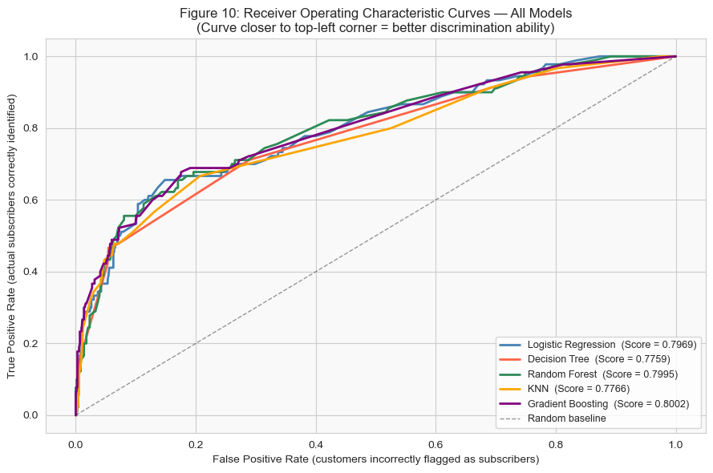

```python
fig, ax = plt.subplots(figsize=(9, 6))

colors = ['steelblue', 'tomato', 'seagreen', 'orange', 'purple']

for (name, probs), color in zip(test_probs.items(), colors):
    fpr, tpr, _ = roc_curve(y_test, probs)
    score = roc_auc_score(y_test, probs)
    ax.plot(fpr, tpr, color=color, linewidth=2,
            label=f'{name}  (Score = {score:.4f})')

ax.plot([0,1], [0,1], 'k--', linewidth=1, alpha=0.4, label='Random baseline')
ax.set_xlabel('False Positive Rate (customers incorrectly flagged as subscribers)')
ax.set_ylabel('True Positive Rate (actual subscribers correctly identified)')
ax.set_title('Figure 10: Receiver Operating Characteristic Curves — All Models\n(Curve closer to top-left corner = better discrimination ability)')
ax.legend(fontsize=9, loc='lower right')
ax.set_facecolor('#f9f9f9')
plt.tight_layout()
plt.show()
```

```python
# pairwise paired t-tests
model_names = list(cv_results.keys())
p_matrix = pd.DataFrame(index=model_names, columns=model_names, dtype=float)

for m1 in model_names:
    for m2 in model_names:
        if m1 == m2:
            p_matrix.loc[m1, m2] = 1.0
        else:
            _, p = stats.ttest_rel(cv_results[m1], cv_results[m2])
            p_matrix.loc[m1, m2] = round(p, 4)

print("Pairwise Paired t-Test p-values (significance level = 0.05):")
print(p_matrix.to_string())
print()
print("Statistically significant differences (p < 0.05):")
for m1 in model_names:
    for m2 in model_names:
        if m1 < m2 and p_matrix.loc[m1, m2] < 0.05:
            print(f"  {m1} vs {m2}: p = {p_matrix.loc[m1, m2]}")
```

```
Pairwise Paired t-Test p-values (significance level = 0.05):
                     Logistic Regression  Decision Tree  Random Forest     KNN  Gradient Boosting
Logistic Regression               1.0000         0.0483         0.1289  0.0222             0.6811
Decision Tree                     0.0483         1.0000         0.3966  0.2821             0.0069
Random Forest                     0.1289         0.3966         1.0000  0.1418             0.0266
KNN                               0.0222         0.2821         0.1418  1.0000             0.0090
Gradient Boosting                 0.6811         0.0069         0.0266  0.0090             1.0000

Statistically significant differences (p < 0.05):
  Decision Tree vs Logistic Regression: p = 0.0483
  Decision Tree vs Gradient Boosting: p = 0.0069
  KNN vs Logistic Regression: p = 0.0222
  Gradient Boosting vs Random Forest: p = 0.0266
  Gradient Boosting vs KNN: p = 0.009
```

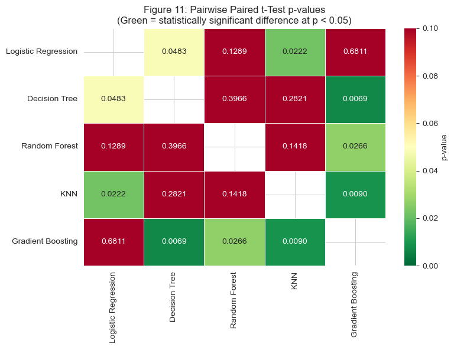

```python
plt.figure(figsize=(8, 6))
mask = np.eye(len(model_names), dtype=bool)

sns.heatmap(p_matrix.astype(float),
            annot=True, fmt='.4f',
            cmap='RdYlGn_r', vmin=0, vmax=0.1,
            linewidths=0.5, linecolor='white',
            mask=mask,
            cbar_kws={'label': 'p-value'})

plt.title('Figure 11: Pairwise Paired t-Test p-values\n(Green = statistically significant difference at p < 0.05)')
plt.tight_layout()
plt.show()
```

**Model comparison findings.** All five models substantially outperform the random baseline. Final rankings by test set score:

| Model | CV Score (Mean ± Std) | Test Score |
| --- | --- | --- |
| Gradient Boosting | 0.7743 ± 0.0516 | 0.8002 |
| Random Forest | 0.7660 ± 0.0511 | 0.7995 |
| Logistic Regression | 0.7764 ± 0.0512 | 0.7969 |
| KNN | 0.7527 ± 0.0519 | 0.7766 |
| Decision Tree | 0.7624 ± 0.0551 | 0.7759 |

Paired t-tests identified statistically significant differences at α=0.05. Gradient Boosting significantly outperformed Decision Tree (p=0.0069), KNN (p=0.0090) and Random Forest (p=0.0266). Logistic Regression significantly outperformed KNN (p=0.0222) and Decision Tree (p=0.0483). Critically, Gradient Boosting and Logistic Regression are statistically indistinguishable (p=0.6811) the most complex model does not meaningfully outperform the simplest. For a bank, this makes Logistic Regression the preferred deployment choice comparable predictive power with greater interpretability and regulatory transparency.

## 3. Critique and Limitations

**Realistic prediction setup.** A major strength of this project is that the modelling process was designed for realistic pre-campaign prediction. The `duration` feature was removed because it is only available after a customer call is completed. Although keeping this variable would likely increase model scores, it would not be useful for predicting customer subscription before contact is made. Removing it therefore improves the practical reliability of the model.

**Class imbalance treatment.** The target variable was highly imbalanced, with far more non-subscribers than subscribers. To reduce this issue, class-weighted models were used during training. This allowed the algorithms to give greater importance to the minority subscription class. However, this approach may still miss some potential subscribers, so future work could compare class weighting with SMOTE, threshold adjustment, or cost-sensitive learning.

**Feature selection limitations.** Feature selection was carried out using ANOVA F-score and Random Forest feature importance. These methods helped reduce unnecessary predictors and focus the models on stronger variables. However, they may not fully capture complex relationships between multiple features. Future work could test Recursive Feature Elimination or regularisation-based selection to improve feature choice.

**Model tuning limitations.** Hyperparameter tuning was performed for all models, but the tuning grids were kept manageable to avoid excessive computation time. This means some stronger parameter combinations may not have been explored. Wider grid search or randomised search could improve performance, especially for ensemble models such as Random Forest and Gradient Boosting.

**Dataset generalisability.** The dataset is based on one bank marketing campaign context, so the results may not generalise perfectly to other banks, countries, or current market conditions. Customer behaviour and economic conditions can change over time. Testing the model on newer and more diverse banking datasets would provide stronger evidence of real-world usefulness.

**Business evaluation limitation.** The models were mainly compared using ROC-AUC and cross-validation performance. While these metrics are useful, they do not fully capture the business cost of wrong predictions. In practice, false positives may lead to wasted calls, while false negatives may mean missing potential subscribers. Future work could include cost-based evaluation or Precision-Recall AUC.

## 4. Summary and Conclusions

### 4.1 Project Summary

This project applied a supervised machine learning pipeline to the Bank Marketing dataset with the objective of predicting whether a customer would subscribe to a term deposit. Phase 1 involved data cleaning, exploratory data analysis, and a literature review that identified key patterns including strong class imbalance, high inter-correlation among economic indicators, and demographic variation in subscription rates.

Five classification algorithms were tuned using 5-fold cross-validation grid and validation search, and evaluated using 10-fold stratified cross-validation: Logistic Regression, Decision Tree, Random Forest, K-Nearest Neighbours, and Gradient Boosting. Model comparison via pairwise paired t-tests on cross-validation score vectors provided statistical evidence for the performance ranking.

### 4.2 Summary of Findings

The main finding from the analysis is that customer subscription behaviour is influenced more strongly by campaign and economic conditions than by simple demographic characteristics. Features such as `nr_employed`, `euribor3m`, `emp_var_rate`, and `cons_price_idx` appeared as important predictors, showing that broader economic conditions play a major role in whether customers are likely to subscribe.

Previous campaign outcome was also an important predictor. Customers who had responded positively in earlier campaigns were more likely to subscribe again, which suggests that historical customer responsiveness is useful for future targeting. This finding supports the idea that banks should not treat all customers equally in marketing campaigns, but instead prioritise customers with stronger signs of previous interest.

### 4.3 Conclusions

Overall, the project successfully achieved its goal of building and comparing machine learning models for term deposit subscription prediction. The modelling process was designed to be realistic by removing the `duration` feature and focusing on information that would be available before customer contact. This makes the final results more useful for practical campaign planning.

Gradient Boosting was selected as the strongest overall model because it achieved the highest test-set ROC-AUC score and showed strong discrimination between subscribers and non-subscribers. However, Logistic Regression should also be considered as a practical deployment option because it produced comparable performance and is easier to explain to business users.

From a business perspective, the findings suggest that banks can improve campaign efficiency by targeting customers based on previous campaign response and economic conditions rather than relying only on basic demographic information. Future work should test the model on more recent data, compare additional imbalance-handling techniques, and include cost-based evaluation to better reflect the real trade-off between wasted calls and missed subscription opportunities.

## 5. References

Moro, S., Rita, P., & Cortez, P. (2014). *Bank Marketing* [Dataset]. UCI Machine Learning Repository. https://doi.org/10.24432/C5K306

Borugadda, P., Nandru, P., & Madhavaiah, C. (2021). Predicting the success of bank telemarketing for selling long-term deposits: An application of machine learning algorithms. St. Theresa Journal of Humanities and Social Sciences, 7(1), 91–108. https://so01.tci-thaijo.org/index.php/STJHSS

Bradley, A. P. (1997). The use of the area under the ROC curve in the evaluation of machine learning algorithms. *Pattern Recognition, 30*(6), 1145–1159. https://doi.org/10.1016/S0031-3203(96)00142-2

Chawla, N. V., Bowyer, K. W., Hall, L. O., & Kegelmeyer, W. P. (2002). SMOTE: Synthetic minority over-sampling technique. *Journal of Artificial Intelligence Research, 16*, 321–357. https://doi.org/10.1613/jair.953

Couronné, R., Probst, P., & Boulesteix, A.-L. (2018). Random forest versus logistic regression: A large-scale benchmark experiment. *BMC Bioinformatics, 19*(1), 270. https://doi.org/10.1186/s12859-018-2264-5

Du, S. (2025). Findings from the bank marketing dataset: Using machine learning to forecast term deposit subscriptions. *Advances in Economics, Management and Political Sciences, 240*, 60–69. https://doi.org/10.54254/2754-1169/2025/20073

Moro, S., Cortez, P., & Rita, P. (2014). A data-driven approach to predict the success of bank telemarketing. *Decision Support Systems, 62*, 22–31. https://doi.org/10.1016/j.dss.2014.03.001

Peter, M., Mofi, H., Likoko, S., Sabas, J., Mbura, R., & Mduma, N. (2025). Predicting customer subscription in bank telemarketing campaigns using ensemble learning models. *Machine Learning with Applications, 19*, 100618. https://doi.org/10.1016/j.mlwa.2025.100618

Pradipta, G. A., Wardoyo, R., Musdholifah, A., Sanjaya, I. N. H., & Ismail, M. (2021, November). SMOTE for handling imbalanced data problem: A review. In *2021 Sixth International Conference on Informatics and Computing (ICIC)* (pp. 1–8). IEEE. https://doi.org/10.1109/ICIC54025.2021.9632912